# Prudential Life Insurance

The dataset used in this analysis is downloaded from kaggle. More information can be found [here.](https://www.kaggle.com/c/prudential-life-insurance-assessment/data) Note that the dataset has already been encoded,and other variables has been normalized.

```python
import pandas as pd
import altair as alt
alt.renderers.enable('notebook')
alt.data_transformers.enable('json')
pd.set_option('display.max_columns', 500)
pd.set_option('display.max_rows', 200)
```

```python
data = pd.read_csv('train.csv')
data.head()
```

|  | Id | Product_Info_1 | Product_Info_2 | Product_Info_3 | Product_Info_4 | Product_Info_5 | Product_Info_6 | Product_Info_7 | Ins_Age | Ht | Wt | BMI | Employment_Info_1 | Employment_Info_2 | Employment_Info_3 | Employment_Info_4 | Employment_Info_5 | Employment_Info_6 | InsuredInfo_1 | InsuredInfo_2 | InsuredInfo_3 | InsuredInfo_4 | InsuredInfo_5 | InsuredInfo_6 | InsuredInfo_7 | Insurance_History_1 | Insurance_History_2 | Insurance_History_3 | Insurance_History_4 | … |
| --- | --- | --- | --- | --- | --- | --- | --- | --- | --- | --- | --- | --- | --- | --- | --- | --- | --- | --- | --- | --- | --- | --- | --- | --- | --- | --- | --- | --- | --- | --- |
| 0 | 2 | 1 | D3 | 10 | 0.076923 | 2 | 1 | 1 | 0.641791 | 0.581818 | 0.148536 | 0.323008 | 0.028 | 12 | 1 | 0.0 | 3 | NaN | 1 | 2 | 6 | 3 | 1 | 2 | 1 | 1 | 1 | 3 | 1 | … |
| 1 | 5 | 1 | A1 | 26 | 0.076923 | 2 | 3 | 1 | 0.059701 | 0.600000 | 0.131799 | 0.272288 | 0.000 | 1 | 3 | 0.0 | 2 | 0.0018 | 1 | 2 | 6 | 3 | 1 | 2 | 1 | 2 | 1 | 3 | 1 | … |
| 2 | 6 | 1 | E1 | 26 | 0.076923 | 2 | 3 | 1 | 0.029851 | 0.745455 | 0.288703 | 0.428780 | 0.030 | 9 | 1 | 0.0 | 2 | 0.0300 | 1 | 2 | 8 | 3 | 1 | 1 | 1 | 2 | 1 | 1 | 3 | … |
| 3 | 7 | 1 | D4 | 10 | 0.487179 | 2 | 3 | 1 | 0.164179 | 0.672727 | 0.205021 | 0.352438 | 0.042 | 9 | 1 | 0.0 | 3 | 0.2000 | 2 | 2 | 8 | 3 | 1 | 2 | 1 | 2 | 1 | 1 | 3 | … |
| 4 | 8 | 1 | D2 | 26 | 0.230769 | 2 | 3 | 1 | 0.417910 | 0.654545 | 0.234310 | 0.424046 | 0.027 | 9 | 1 | 0.0 | 2 | 0.0500 | 1 | 2 | 6 | 3 | 1 | 2 | 1 | 2 | 1 | 1 | 3 | … |

```python
data.describe()
```

|  | Id | Product_Info_1 | Product_Info_3 | Product_Info_4 | Product_Info_5 | Product_Info_6 | Product_Info_7 | Ins_Age | Ht | Wt | BMI | Employment_Info_1 | Employment_Info_2 | Employment_Info_3 | Employment_Info_4 | Employment_Info_5 | Employment_Info_6 | InsuredInfo_1 | InsuredInfo_2 | InsuredInfo_3 | InsuredInfo_4 | InsuredInfo_5 | InsuredInfo_6 | InsuredInfo_7 | Insurance_History_1 | Insurance_History_2 | Insurance_History_3 | Insurance_History_4 | Insurance_History_5 | … |
| --- | --- | --- | --- | --- | --- | --- | --- | --- | --- | --- | --- | --- | --- | --- | --- | --- | --- | --- | --- | --- | --- | --- | --- | --- | --- | --- | --- | --- | --- | --- |
| count | 59381.000000 | 59381.000000 | 59381.000000 | 59381.000000 | 59381.000000 | 59381.000000 | 59381.000000 | 59381.000000 | 59381.000000 | 59381.000000 | 59381.000000 | 59362.000000 | 59381.000000 | 59381.000000 | 52602.000000 | 59381.000000 | 48527.000000 | 59381.000000 | 59381.000000 | 59381.000000 | 59381.000000 | 59381.000000 | 59381.000000 | 59381.000000 | 59381.000000 | 59381.000000 | 59381.000000 | 59381.000000 | 33985.000000 | … |
| mean | 39507.211515 | 1.026355 | 24.415655 | 0.328952 | 2.006955 | 2.673599 | 1.043583 | 0.405567 | 0.707283 | 0.292587 | 0.469462 | 0.077582 | 8.641821 | 1.300904 | 0.006283 | 2.142958 | 0.361469 | 1.209326 | 2.007427 | 5.835840 | 2.883666 | 1.027180 | 1.409188 | 1.038531 | 1.727606 | 1.055792 | 2.146983 | 1.958707 | 0.001733 | … |
| std | 22815.883089 | 0.160191 | 5.072885 | 0.282562 | 0.083107 | 0.739103 | 0.291949 | 0.197190 | 0.074239 | 0.089037 | 0.122213 | 0.082347 | 4.227082 | 0.715034 | 0.032816 | 0.350033 | 0.349551 | 0.417939 | 0.085858 | 2.674536 | 0.320627 | 0.231566 | 0.491688 | 0.274915 | 0.445195 | 0.329328 | 0.989139 | 0.945739 | 0.007338 | … |
| min | 2.000000 | 1.000000 | 1.000000 | 0.000000 | 2.000000 | 1.000000 | 1.000000 | 0.000000 | 0.000000 | 0.000000 | 0.000000 | 0.000000 | 1.000000 | 1.000000 | 0.000000 | 2.000000 | 0.000000 | 1.000000 | 2.000000 | 1.000000 | 2.000000 | 1.000000 | 1.000000 | 1.000000 | 1.000000 | 1.000000 | 1.000000 | 1.000000 | 0.000000 | … |
| 25% | 19780.000000 | 1.000000 | 26.000000 | 0.076923 | 2.000000 | 3.000000 | 1.000000 | 0.238806 | 0.654545 | 0.225941 | 0.385517 | 0.035000 | 9.000000 | 1.000000 | 0.000000 | 2.000000 | 0.060000 | 1.000000 | 2.000000 | 3.000000 | 3.000000 | 1.000000 | 1.000000 | 1.000000 | 1.000000 | 1.000000 | 1.000000 | 1.000000 | 0.000400 | … |
| 50% | 39487.000000 | 1.000000 | 26.000000 | 0.230769 | 2.000000 | 3.000000 | 1.000000 | 0.402985 | 0.709091 | 0.288703 | 0.451349 | 0.060000 | 9.000000 | 1.000000 | 0.000000 | 2.000000 | 0.250000 | 1.000000 | 2.000000 | 6.000000 | 3.000000 | 1.000000 | 1.000000 | 1.000000 | 2.000000 | 1.000000 | 3.000000 | 2.000000 | 0.000973 | … |
| 75% | 59211.000000 | 1.000000 | 26.000000 | 0.487179 | 2.000000 | 3.000000 | 1.000000 | 0.567164 | 0.763636 | 0.345188 | 0.532858 | 0.100000 | 9.000000 | 1.000000 | 0.000000 | 2.000000 | 0.550000 | 1.000000 | 2.000000 | 8.000000 | 3.000000 | 1.000000 | 2.000000 | 1.000000 | 2.000000 | 1.000000 | 3.000000 | 3.000000 | 0.002000 | … |
| max | 79146.000000 | 2.000000 | 38.000000 | 1.000000 | 3.000000 | 3.000000 | 3.000000 | 1.000000 | 1.000000 | 1.000000 | 1.000000 | 1.000000 | 38.000000 | 3.000000 | 1.000000 | 3.000000 | 1.000000 | 3.000000 | 3.000000 | 11.000000 | 3.000000 | 3.000000 | 2.000000 | 3.000000 | 2.000000 | 3.000000 | 3.000000 | 3.000000 | 1.000000 | … |

```python
missing = pd.DataFrame(data.isnull().sum())
missing = missing[missing[0]>0]
missing.columns = ['count of missing']
missing['% of total'] = (missing['count of missing']/data.shape[0])*100
missing
```

|  | count of missing | % of total |
| --- | --- | --- |
| Employment_Info_1 | 19 | 0.031997 |
| Employment_Info_4 | 6779 | 11.416110 |
| Employment_Info_6 | 10854 | 18.278574 |
| Insurance_History_5 | 25396 | 42.767889 |
| Family_Hist_2 | 28656 | 48.257860 |
| Family_Hist_3 | 34241 | 57.663226 |
| Family_Hist_4 | 19184 | 32.306630 |
| Family_Hist_5 | 41811 | 70.411411 |
| Medical_History_1 | 8889 | 14.969435 |
| Medical_History_10 | 58824 | 99.061990 |
| Medical_History_15 | 44596 | 75.101463 |
| Medical_History_24 | 55580 | 93.598963 |
| Medical_History_32 | 58274 | 98.135767 |

```python
print('Columns with more than 70% missing values:')
print(list(missing[missing['% of total']>70].index))
```

```
Columns with more than 70% missing values:
['Family_Hist_5', 'Medical_History_10', 'Medical_History_15', 'Medical_History_24', 'Medical_History_32']
```

```python
data.drop(['Family_Hist_5', 'Medical_History_10', 'Medical_History_15', 'Medical_History_24', 'Medical_History_32'],axis=1,inplace=True)
```

## Target Distribution

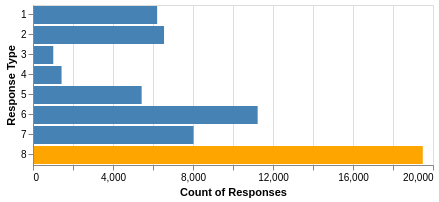

```python
alt.Chart(data).mark_bar().encode(
    y = alt.Y('Response:O',title = 'Response Type'),
    x = alt.X('count()',title='Count of Responses'),
        color=alt.condition(
        alt.datum.Response == 8,
        alt.value('orange'),
        alt.value('steelblue')
    )
)
```

## Age, Height, Weight and BMI Cross Filter

Note that all of these features has been normalized (i.e. they're now all between 0-1) Note that the **age** column has a more wider distribution. Also, since the plot below is interactive (highlighting from one bar plot also highlights other bar plots) we can see how all 4 distributions are changing.

This reveals that,

- The right hand side of height takes the same portion of the distribution of the other 3 variables.
- ~ < 0.60 of the **age** columns takes up most of the other distributions.

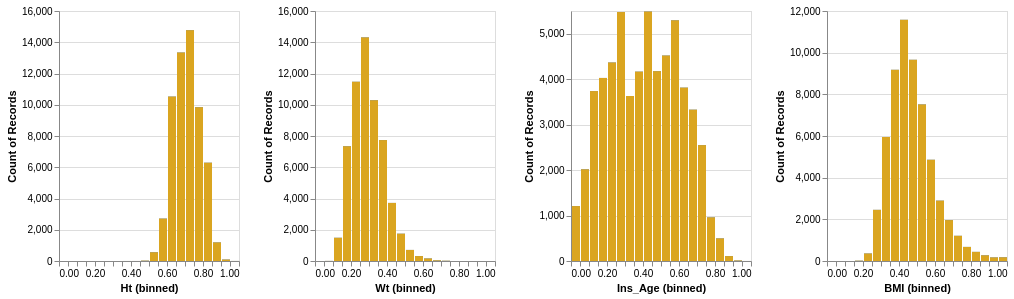

```python
brush = alt.selection(type='interval', encodings=['x'])


base = alt.Chart().mark_bar().encode(
    x=alt.X(alt.repeat('column'), type='quantitative', bin=alt.Bin(maxbins=20)),
    y='count()'
).properties(
    width=180,
    height=250
)


background = base.add_selection(brush)

# yellow highlights on the transformed data
highlight = base.encode(
    color=alt.value('goldenrod')
).transform_filter(brush)


alt.layer(
    background,
    highlight,
    data=data
).repeat(column=["Ht", "Wt", "Ins_Age", "BMI"])
```

# Distribution by Product Info

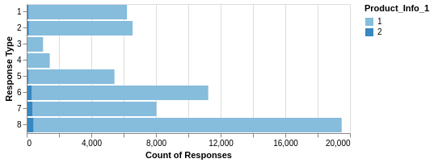

```python
alt.Chart(data).mark_bar().encode(
    y = alt.Y('Response:O',title = 'Response Type'),
    x = alt.X('count()',title='Count of Responses'),
    color = 'Product_Info_1:O'
)
```

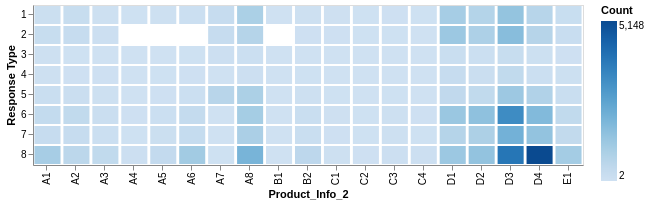

```python
alt.Chart(data).mark_bar().encode(
    y = alt.Y('Response:O',title = 'Response Type'),
    color = alt.X('count()',title='Count'),
    x = 'Product_Info_2:O'
).properties(width=550)
```

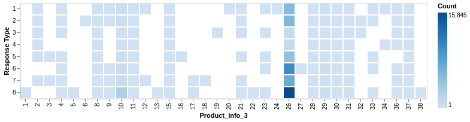

```python
alt.Chart(data).mark_bar().encode(
    y = alt.Y('Response:O',title = 'Response Type'),
    color = alt.X('count()',title='Count'),
    x = 'Product_Info_3:O'
)
```

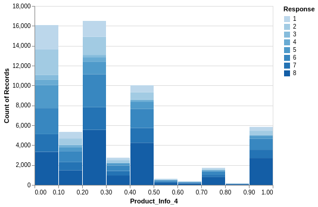

```python
alt.Chart(data).mark_bar().encode(
    x = alt.X('Product_Info_4:Q',title = 'Product_Info_4',bin=True),
    y = 'count()',
    color = 'Response:O'
)
```

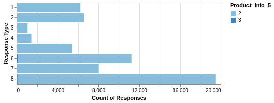

```python
alt.Chart(data).mark_bar().encode(
    y = alt.Y('Response:O',title = 'Response Type'),
    x = alt.X('count()',title='Count of Responses'),
    color = 'Product_Info_5:O'
)
```